# TUGAS MINGGU 5 MPDW

Fajryanti Kusuma Wardani

```r
library(ggplot2)
library(tsibble)
library(tseries)
library(MASS)
```

```r
#IMPORT DATA
#Menggunakan data dari minggu ke-1
library("rio")
data5 <- import("https://raw.githubusercontent.com/fajryanti/mpdw-p1/main/PRAKTIKUM%20MINGGU%205/TWTR.csv")
data5 <- data5[2000:2199,]
data5
```

```
##            Date      Open      High       Low     Close Adj Close    Volume
## 2000 2021-10-18 62.689999 65.065002 62.669998 64.839996 64.839996  10359530
## 2001 2021-10-19 65.139999 67.360001 64.300003 66.110001 66.110001  11486884
## 2002 2021-10-20 66.360001 68.410004 65.540001 65.800003 65.800003  15938354
## 2003 2021-10-21 65.669998 65.980003 64.730003 65.400002 65.400002  10918515
## 2004 2021-10-22 63.810001 64.470001 62.090000 62.240002 62.240002  17636449
## 2005 2021-10-25 61.520000 62.669998 60.450001 62.110001 62.110001  15874510
## 2006 2021-10-26 62.660000 63.080002 60.939999 61.430000 61.430000  22676075
## 2007 2021-10-27 60.049999 60.160000 54.785000 54.810001 54.810001  48107729
## 2008 2021-10-28 55.080002 55.639999 53.889999 54.290001 54.290001  22508364
## 2009 2021-10-29 54.009998 54.480000 53.150002 53.540001 53.540001  14832438
## 2010 2021-11-01 53.560001 55.330002 53.410099 55.110001 55.110001  14747011
## 2011 2021-11-02 55.040001 55.080002 53.775002 53.990002 53.990002  11571394
## 2012 2021-11-03 53.680000 54.549999 53.099998 54.529999 54.529999   9774196
## 2013 2021-11-04 54.580002 54.840000 53.180000 53.680000 53.680000  11284746
```

[output cut: 186 more lines]

## Stasioner dalam Rataan dan Ragam

```r
stas <- ts(data5$Open)
stas
```

```
## Time Series:
## Start = 1
## End = 200
## Frequency = 1
##   [1] 62.689999 65.139999 66.360001 65.669998 63.810001 61.520000 62.660000
##   [8] 60.049999 55.080002 54.009998 53.560001 55.040001 53.680000 54.580002
##  [15] 54.110001 53.450001 54.110001 53.250000 52.590000 52.299999 52.410000
##  [22] 52.860001 52.029999 50.650002 49.119999 48.509998 47.200001 46.660000
##  [29] 46.639999 51.880001 45.509998 44.910000 43.060001 42.820000 42.110001
##  [36] 45.070000 44.599998 47.209999 46.599998 45.549999 44.040001 44.000000
##  [43] 44.430000 42.700001 42.369999 43.230000 44.049999 44.000000 44.209999
##  [50] 44.209999 43.169998 42.770000 44.340000 43.500000 42.849998 40.799999
##  [57] 39.500000 39.650002 39.330002 39.790001 40.880001 40.150002 38.430000
##  [64] 37.720001 37.130001 37.840000 36.900002 33.700001 34.220001 34.970001
##  [71] 34.139999 33.790001 35.430000 37.840000 38.290001 33.840000 35.660000
```

[output cut: 18 more lines]

### Plot *Time Series*

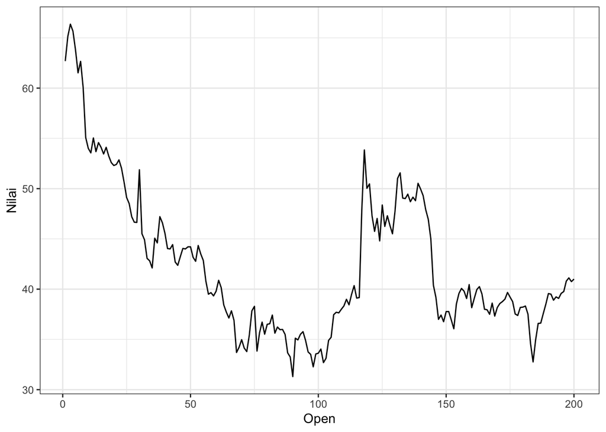

```r
plot_stas <- stas |> as_tsibble() |>
  ggplot(aes(x = index, y = value)) + geom_line() + theme_bw() +
  xlab("Open") + ylab("Nilai")
plot_stas
```

```r
mean(stas)
```

[output not shown]

Plot deret waktu di atas menunjukkan bahwa data tidak stasioner dalam rataan, ditandai dengan lebar pita yang cenderung tidak sama.

### Plot ACF

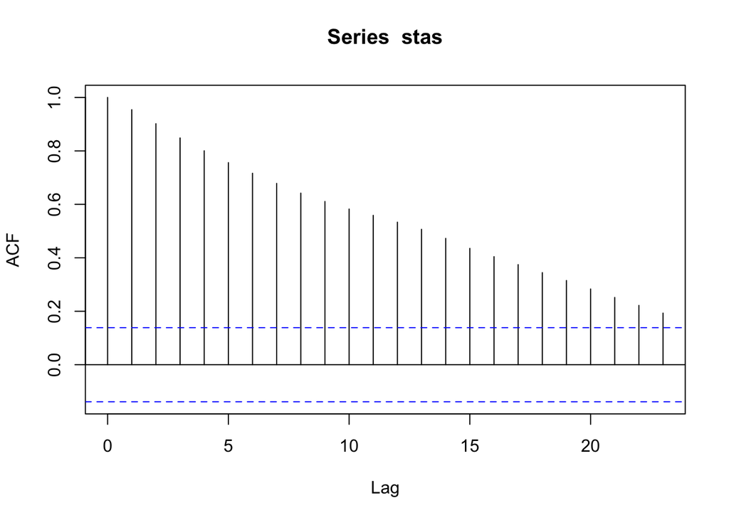

```r
stas <- as.numeric(stas)
acf(stas)
```

Berdasarkan plot ACF, terlihat bahwa plot ACF pada data tersebut cenderung *tails off slowly* dan tidak membentuk gelombang sinus.

### Uji ADF

```r
tseries::adf.test(stas)
```

```
##
##  Augmented Dickey-Fuller Test
##
## data:  stas
## Dickey-Fuller = -2.6959, Lag order = 5, p-value = 0.2847
## alternative hypothesis: stationary
```

$H_0$ : Data tidak stasioner dalam rataan

$H_1$ : Data stasioner dalam rataan

Berdasarkan uji ADF tersebut, didapat *p-value* sebesar 0.2847 yang lebih besar dari taraf nyata 5% sehingga tak tolak $H_0$ dan menandakan bahwa data tidak stasioner dalam rataan. Hal ini sesuai dengan hasil eksplorasi menggunakan plot time series dan plot ACF.

### Plot Box-Cox

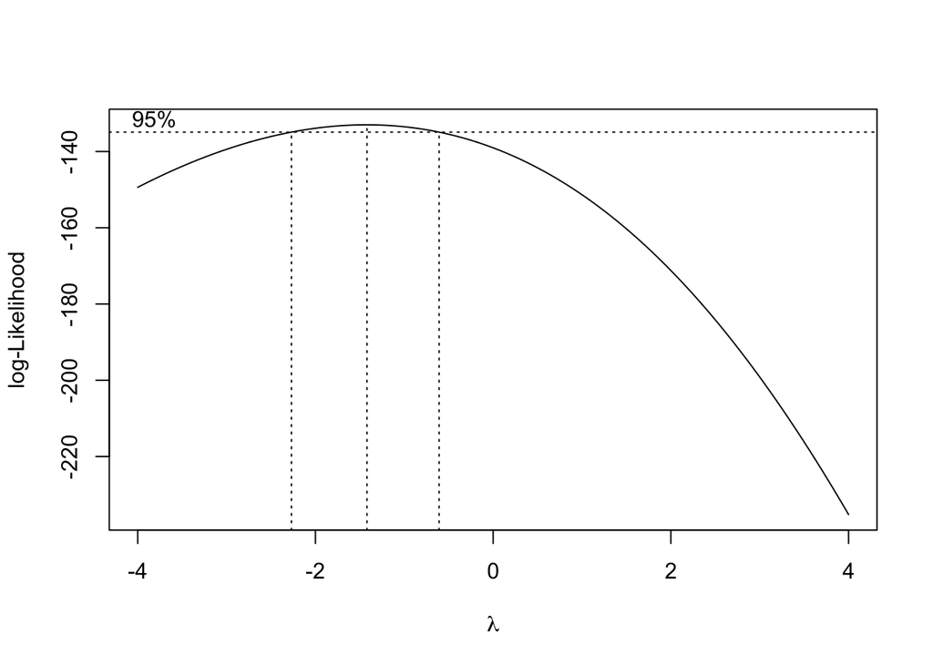

```r
stas <- as.numeric(stas)
index <- seq(1:200)
bc = boxcox(stas ~ index, lambda = seq(-4,4,by=0.01))
```

```r
#Nilai Rounded Lambda
lambda <- bc$x[which.max(bc$y)]
lambda
```

```
## [1] -1.42
```

```r
#SK
bc$x[bc$y > max(bc$y) - 1/2 * qchisq(.95,1)]
```

```
##   [1] -2.27 -2.26 -2.25 -2.24 -2.23 -2.22 -2.21 -2.20 -2.19 -2.18 -2.17 -2.16
##  [13] -2.15 -2.14 -2.13 -2.12 -2.11 -2.10 -2.09 -2.08 -2.07 -2.06 -2.05 -2.04
##  [25] -2.03 -2.02 -2.01 -2.00 -1.99 -1.98 -1.97 -1.96 -1.95 -1.94 -1.93 -1.92
##  [37] -1.91 -1.90 -1.89 -1.88 -1.87 -1.86 -1.85 -1.84 -1.83 -1.82 -1.81 -1.80
##  [49] -1.79 -1.78 -1.77 -1.76 -1.75 -1.74 -1.73 -1.72 -1.71 -1.70 -1.69 -1.68
##  [61] -1.67 -1.66 -1.65 -1.64 -1.63 -1.62 -1.61 -1.60 -1.59 -1.58 -1.57 -1.56
##  [73] -1.55 -1.54 -1.53 -1.52 -1.51 -1.50 -1.49 -1.48 -1.47 -1.46 -1.45 -1.44
##  [85] -1.43 -1.42 -1.41 -1.40 -1.39 -1.38 -1.37 -1.36 -1.35 -1.34 -1.33 -1.32
##  [97] -1.31 -1.30 -1.29 -1.28 -1.27 -1.26 -1.25 -1.24 -1.23 -1.22 -1.21 -1.20
## [109] -1.19 -1.18 -1.17 -1.16 -1.15 -1.14 -1.13 -1.12 -1.11 -1.10 -1.09 -1.08
## [121] -1.07 -1.06 -1.05 -1.04 -1.03 -1.02 -1.01 -1.00 -0.99 -0.98 -0.97 -0.96
## [133] -0.95 -0.94 -0.93 -0.92 -0.91 -0.90 -0.89 -0.88 -0.87 -0.86 -0.85 -0.84
## [145] -0.83 -0.82 -0.81 -0.80 -0.79 -0.78 -0.77 -0.76 -0.75 -0.74 -0.73 -0.72
## [157] -0.71 -0.70 -0.69 -0.68 -0.67 -0.66 -0.65 -0.64 -0.63 -0.62 -0.61
```

Gambar di atas menunjukkan nilai *rounded value* ($\lambda$) optimum sebesar **-1.42** dan pada selang kepercayaan 95% nilai memiliki batas bawah **-2.27** dan batas atas **-0.61**. Selang tersebut tidak memuat nilai satu sehingga dapat dikatakan bahwa data bangkitan tidak stasioner dalam ragam.

### Partisi Data

#### Bagian 1

```r
dt_stas1 <- stas[1:65] |> ts()
mean(dt_stas1)
```

```
## [1] 48.40477
```

```r
var(dt_stas1)
```

```
## [1] 56.79281
```

#### Plot Time Series

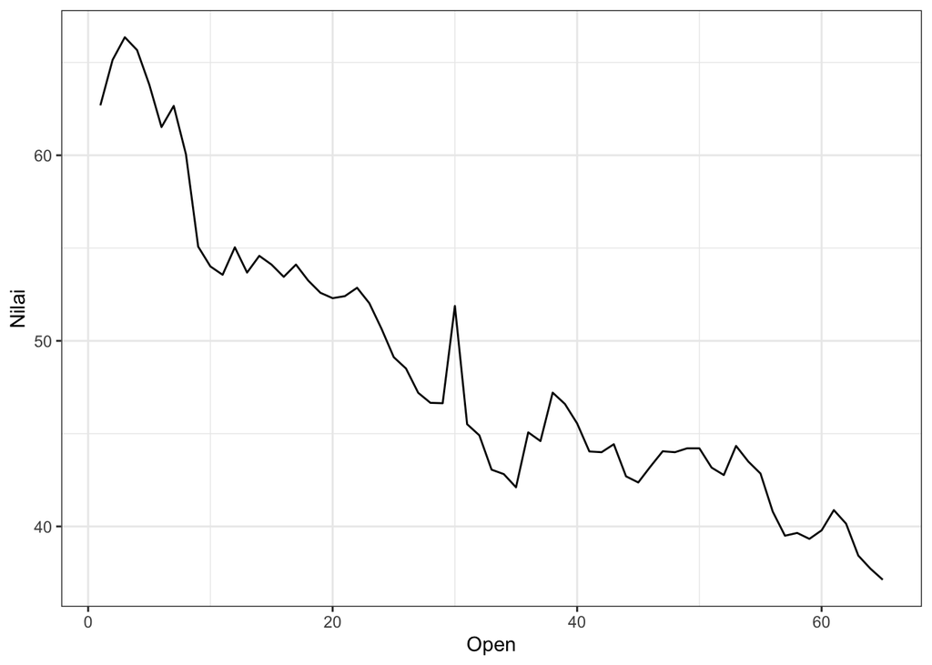

```r
dt_stas1 |> as_tsibble() |>
  ggplot(aes(x = index, y = value)) +
  geom_line() + theme_bw() +
  xlab("Open") + ylab("Nilai")
```

Plot deret waktu di atas menunjukkan bahwa data tidak stasioner dalam rataan, ditandai dengan lebar pita yang cenderung tidak sama.

#### Plot ACF

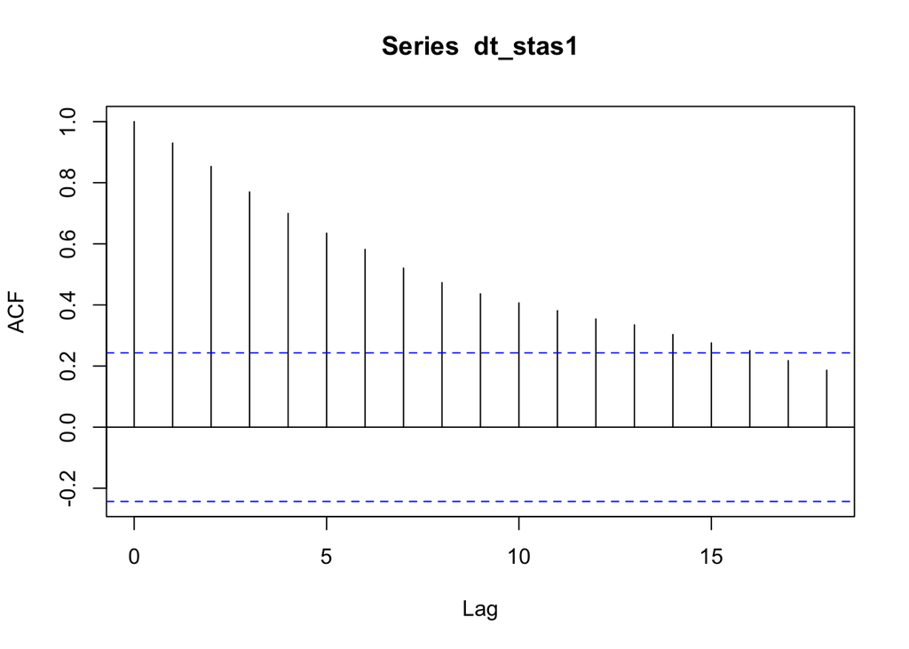

```r
acf(dt_stas1)
```

Berdasarkan plot ACF, terlihat bahwa plot ACF pada data tersebut cenderung *tails off slowly* dan tidak membentuk gelombang sinus.

#### Uji ADF

```r
tseries::adf.test(dt_stas1)
```

```
##
##  Augmented Dickey-Fuller Test
##
## data:  dt_stas1
## Dickey-Fuller = -3.2362, Lag order = 3, p-value = 0.08972
## alternative hypothesis: stationary
```

$H_0$ : Data tidak stasioner dalam rataan

$H_1$ : Data stasioner dalam rataan

Berdasarkan uji ADF tersebut, didapat *p-value* sebesar 0.08972 yang lebih besar dari taraf nyata 5% sehingga tak tolak $H_0$ dan menandakan bahwa data tidak stasioner dalam rataan. Hal ini sesuai dengan hasil eksplorasi menggunakan plot time series dan plot ACF.

#### Plot Boxcox

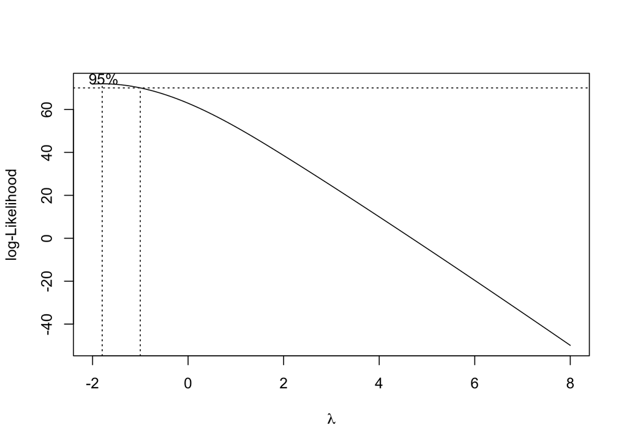

```r
index <- seq(1:65)
bc = boxcox(dt_stas1~index, lambda = seq(-2,8,by=2))
```

```r
#Nilai Rounded Lambda
lambda <- bc$x[which.max(bc$y)]
lambda
```

[output not shown]

```r
#SK
bc$x[bc$y > max(bc$y) - 1/2 * qchisq(.95,1)]
```

```
##  [1] -2.000000 -1.898990 -1.797980 -1.696970 -1.595960 -1.494949 -1.393939
##  [8] -1.292929 -1.191919 -1.090909
```

Gambar di atas menunjukkan nilai *rounded value* ($\lambda$) optimum sebesar **-1.79798** dan pada selang kepercayaan 95% nilai memiliki batas bawah **-2.0** dan batas atas **-1.0909**. Selang tersebut tidak memuat nilai satu sehingga dapat dikatakan bahwa data bangkitan tidak stasioner dalam ragam.

#### Bagian 2

```r
dt_stas2 <- stas[66:200] |> ts()
mean(dt_stas2)
```

```
## [1] 39.50208
```

```r
var(dt_stas2)
```

```
## [1] 25.88124
```

#### Plot Time Series

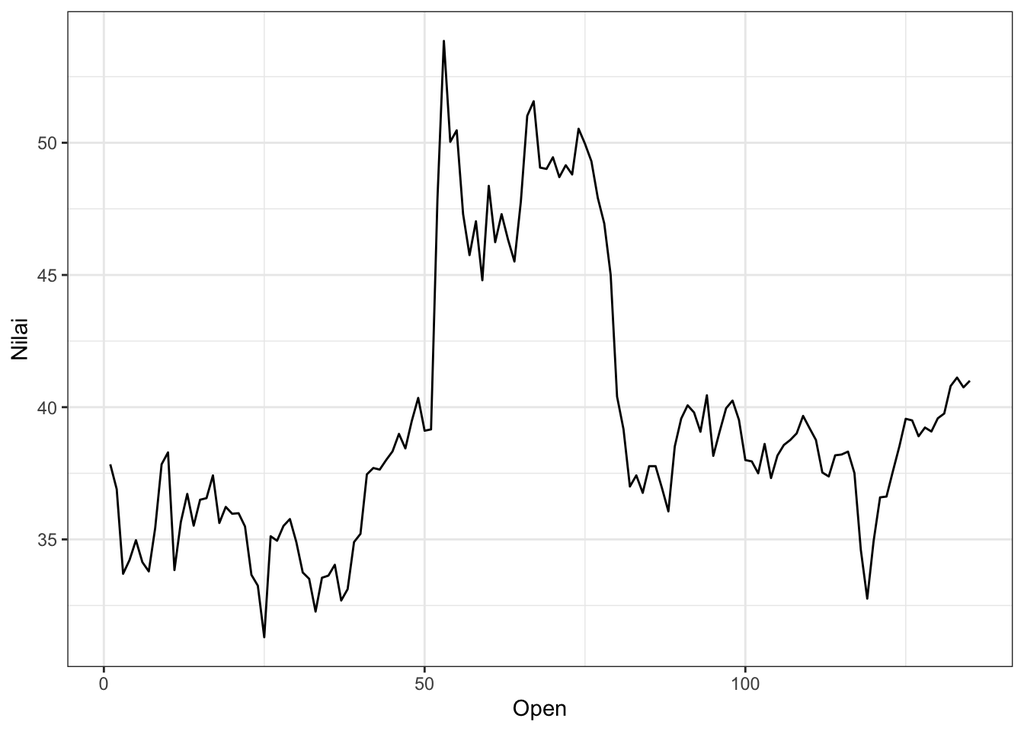

```r
dt_stas2 |> as_tsibble() |>
  ggplot(aes(x = index, y = value)) +
  geom_line() + theme_bw() +
  xlab("Open") + ylab("Nilai")
```

Plot deret waktu di atas menunjukkan bahwa data tidak stasioner dalam rataan, ditandai dengan lebar pita yang cenderung tidak sama.

#### Plot ACF

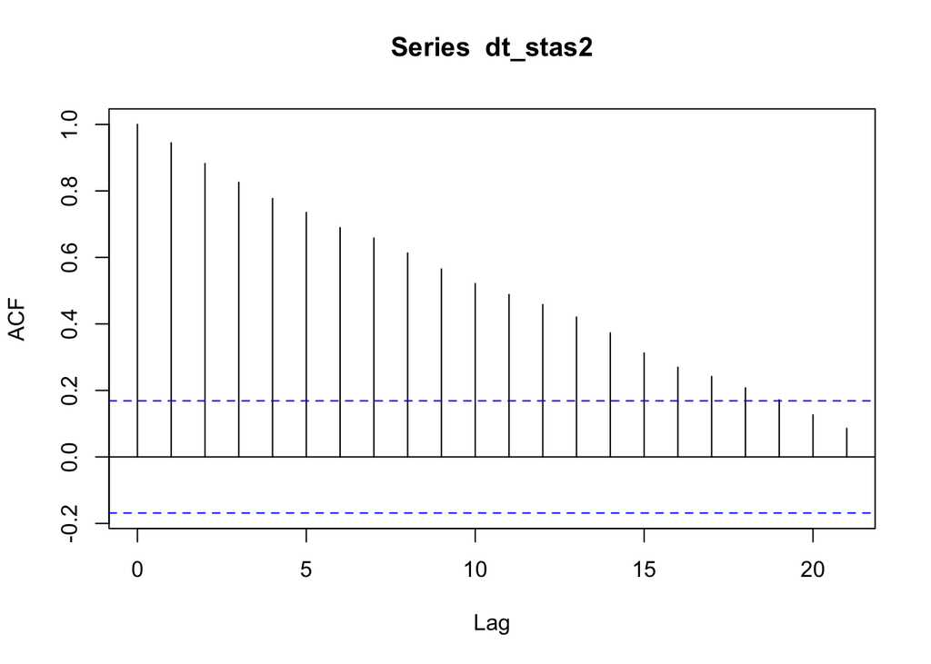

```r
acf(dt_stas2)
```

Berdasarkan plot ACF, terlihat bahwa plot ACF pada data tersebut cenderung *tails off slowly* dan tidak membentuk gelombang sinus.

#### Uji ADF

```r
adf.test(dt_stas2)
```

```
##
##  Augmented Dickey-Fuller Test
##
## data:  dt_stas2
## Dickey-Fuller = -1.8986, Lag order = 5, p-value = 0.6187
## alternative hypothesis: stationary
```

$H_0$ : Data tidak stasioner dalam rataan

$H_1$ : Data stasioner dalam rataan

#### Plot Boxcox

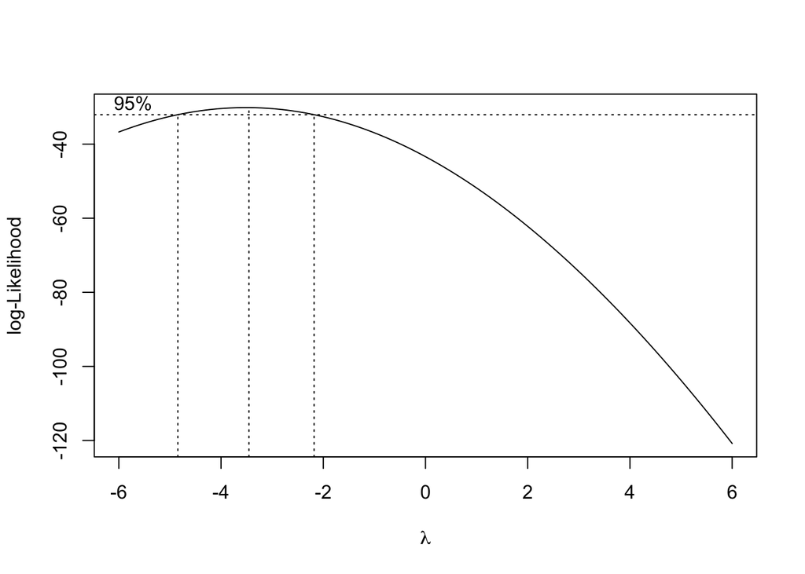

```r
index <- seq(66:200)
bc = boxcox(dt_stas2~index, lambda = seq(-6,6,by=1))
```

```r
#Nilai Rounded Lambda
lambda <- bc$x[which.max(bc$y)]
lambda
```

[output not shown]

```r
#SK
bc$x[bc$y > max(bc$y) - 1/2 * qchisq(.95,1)]
```

```
##  [1] -4.787879 -4.666667 -4.545455 -4.424242 -4.303030 -4.181818 -4.060606
##  [8] -3.939394 -3.818182 -3.696970 -3.575758 -3.454545 -3.333333 -3.212121
## [15] -3.090909 -2.969697 -2.848485 -2.727273 -2.606061 -2.484848 -2.363636
## [22] -2.242424
```